```python
import pandas as pd
import numpy as np
import matplotlib.pyplot as plt
import seaborn as sns
from sklearn.model_selection import train_test_split
from scipy import stats
from scipy.stats import norm
%matplotlib inline
sns.set()
```

# Load Dataset

```python
df = pd.read_csv('full.csv')
```

**Delete Some Features**

```python
df = df.drop(['Unnamed: 0', 'URL', 'URL2', 'Map', 'INSPECTION',\
              'PropertyType', 'SFRCONDO', 'COMPLEXID', 'RecordingDate'], axis = 1)
print('Dataset: {}'.format(df.shape))
```

```
Dataset: (52918, 40)
```

# Clean

**Original Dataset Size**

```python
print('Dataset: {}'.format(df.shape))
```

```
Dataset: (52918, 40)
```

**Drop Duplicated Rows**

```python
df = df.drop_duplicates()
print('Dataset: {}'.format(df.shape))
```

```
Dataset: (36880, 40)
```

Remove Extreme SalePrice Rows  
0.5% SalePrice on the right side  
SalePrice < 1000

```python
df = df[df['SalePrice'] < df['SalePrice'].quantile(0.995)]
df = df[df['SalePrice'] >= 1000]
print('Dataset: {}'.format(df.shape))
```

```
Dataset: (36502, 40)
```

**Drop More Features**

```python
df = df.drop(['PARCEL', 'SequenceNum', 'SaleDate', 'IntendedUse',\
              'Deed', 'ValidationDescription', 'BuyerSellerRelated',\
              'Solar', 'PersonalProperty', 'PartialInterest', 'STORIES',\
              'WALLS', 'ROOF', 'HEAT', 'COOL'], axis = 1)
print('Dataset: {}'.format(df.shape))
```

```
Dataset: (36502, 25)
```

**Remove Price Features**

```python
df = df.drop(['PrPerSqFt', 'ACTUAL', 'MAIN', 'CONTROL'], axis = 1)
print('Dataset: {}'.format(df.shape))
```

```
Dataset: (36502, 21)
```

# Feature Selection

## Deal with float64 & int64 variables

```python
num_cols = [col for col in df.columns.values if (df[col].dtypes == 'float64') or (df[col].dtypes == 'int64')]
num_cols.remove('SalePrice')
corr_coef = []
for c in num_cols:
    cc = np.corrcoef(df[c].values, df['SalePrice'].values)[0, 1]
    corr_coef.append(cc)
```

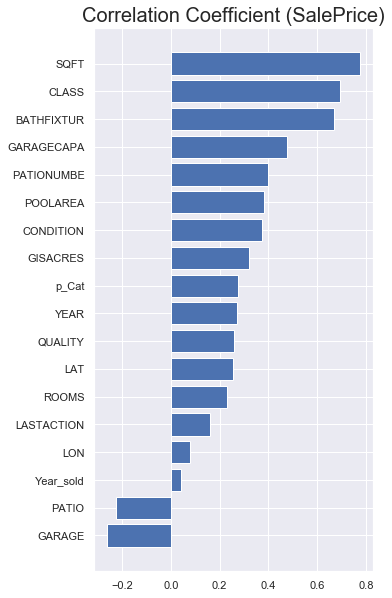

```python
df_cc = pd.DataFrame({'attr': num_cols, 'corr_coef': corr_coef})
df_cc = df_cc.sort_values(by = 'corr_coef')
plt.figure(figsize = (5, 10))
plt.barh(np.arange(len(df_cc)), df_cc['corr_coef'].values)
plt.yticks(np.arange(len(df_cc)), labels = df_cc['attr'].values)
plt.title('Correlation Coefficient (SalePrice)', fontsize = 20)
```

**Select Features with |Correlation Coefficient| > 0.2**  
**Keep:** GARAGE, PATIO, ROOMS, LAT, QUALITY, p_Cat  
**Keep:** CONDITION, GISACRES, POOLAREA, PATIONUMBE  
**Keep:** GARAGECAPA, CLASS, SQFT  
**Remove:** YEAR, BATHFIXTUR

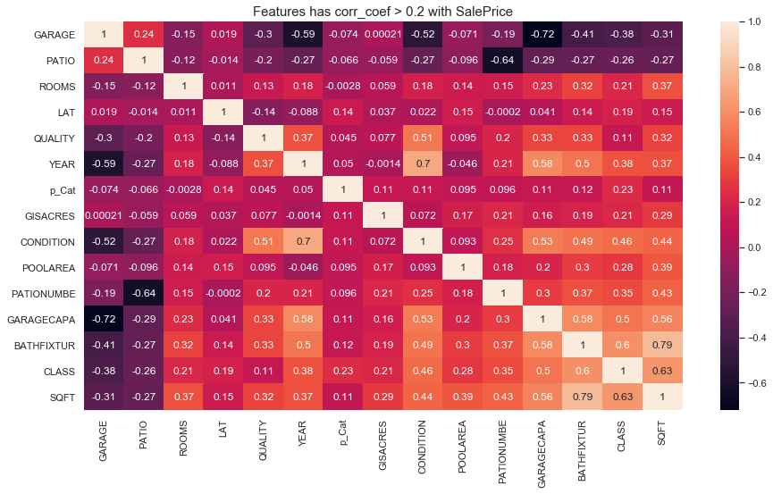

```python
cols = df_cc[abs(df_cc['corr_coef']) > 0.2].attr.values.tolist()
plt.figure(figsize = (15, 8))
sns.heatmap(df[cols].corr(), annot = True)
plt.title('Features has corr_coef > 0.2 with SalePrice', fontsize = 15)
```

**Correlation Coefficient Descend Order**  
SQFT, CLASS, GARAGECAPA, PATIONUMBE, POOLAREA, CONDITION, GISACRES, p_Cat, QUALITY, LAT, ROOMS, GARAGE, PATIO

**Drop Features**  
POOLAREA (continues Variable, but with 2 bars)  
PATIO (low cc, and there is PATIONUMBE alread)

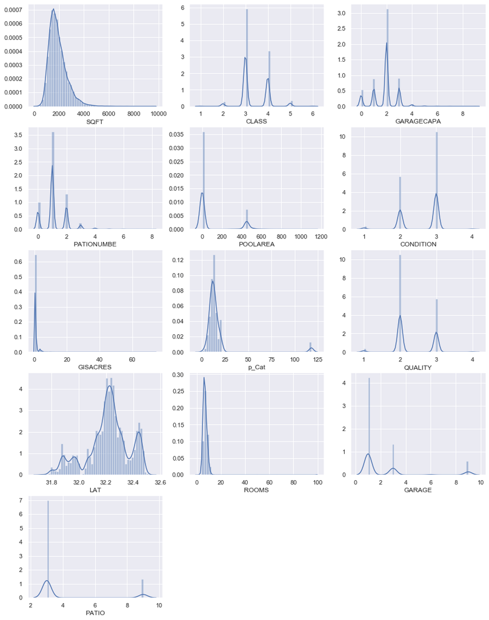

```python
cols = ['SQFT', 'CLASS', 'GARAGECAPA', 'PATIONUMBE', 'POOLAREA', 'CONDITION',\
        'GISACRES', 'p_Cat', 'QUALITY', 'LAT', 'ROOMS', 'GARAGE', 'PATIO']
plt.figure(figsize = (15, 20))
for i in range(13):
    plt.subplot(5, 3, i+1)
    sns.distplot(df[cols[i]])
```

**Check GISACRES**

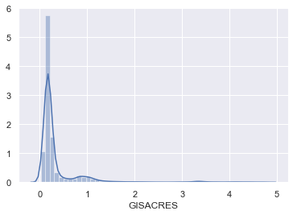

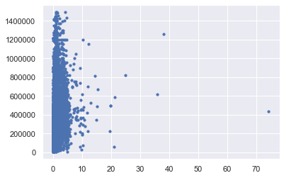

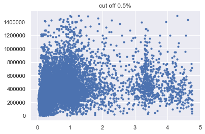

```python
plt.figure(); sns.distplot(df[df['GISACRES'] < df['GISACRES'].quantile(0.995)]['GISACRES'])
plt.figure(); plt.scatter(df['GISACRES'], df['SalePrice'], s = 10)
plt.figure(); plt.scatter(df[df['GISACRES'] < df['GISACRES'].quantile(0.995)]['GISACRES'],\
                          df[df['GISACRES'] < df['GISACRES'].quantile(0.995)]['SalePrice'], s = 10)
plt.title('cut off 0.5%')
```

## Deal with object

```python
obj_cols = [col for col in df.columns.values if (df[col].dtypes == 'object')]
obj_cols
```

```
['Financing', 'ZIP']
```

# Multi Linear Regression

## Use np.log(variable) to plot

**num_cols** = ['SQFT', 'CLASS', 'GARAGECAPA', 'PATIONUMBE', 'CONDITION',  
'GISACRES', 'p_Cat', 'QUALITY', 'LAT', 'ROOMS', 'GARAGE']  
**obj_cols** = ['Financing', 'ZIP']

**SQFT and SalePrice**

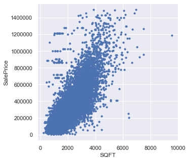

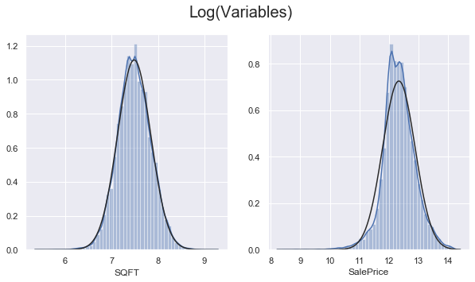

```python
plt.figure(figsize = (10, 5));
plt.subplot(121); plt.scatter(df['SQFT'], df['SalePrice'], s = 10)
plt.xlabel('SQFT'); plt.ylabel('SalePrice')
plt.subplot(122); plt.scatter(np.log(df['SQFT']), np.log(df['SalePrice']), s = 10)
plt.xlabel('log(SQFT)'); plt.ylabel('log(SalePrice)')
plt.figure(figsize = (10, 5))
plt.subplot(121); sns.distplot(np.log(df['SQFT']), fit = norm)
plt.subplot(122); sns.distplot(np.log(df['SalePrice']), fit = norm)
plt.suptitle('Log(Variables)', fontsize = 20)
```

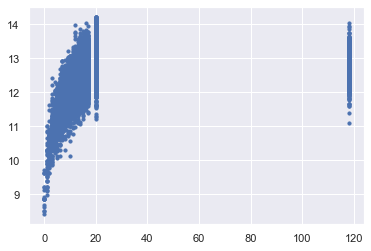

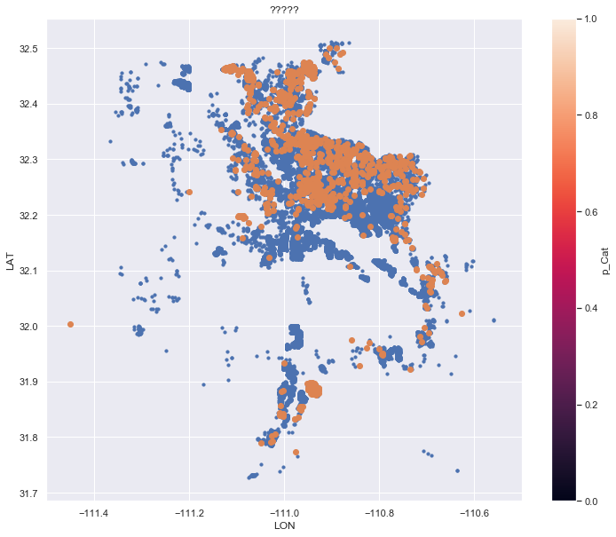

```python
plt.figure(); plt.scatter(df['p_Cat'], np.log(df['SalePrice']), s = 10)
plt.figure(figsize = (12, 10))
plt.scatter(df['LON'], df['LAT'], s = 10)
plt.scatter(df[df['p_Cat'] > 100]['LON'], df[df['p_Cat'] > 100]['LAT'])
cb = plt.colorbar()
cb.set_label('p_Cat')
plt.xlim([-111.5, -110.5])
plt.xlabel('LON'); plt.ylabel('LAT')
plt.title('?????')
```

**One Hot Encoding Financing**

```python
d = np.zeros(len(df))
for i in range(len(df.Financing.values)):
    if df.Financing.values[i] == 'Cash':
        d[i] = 1
    elif df.Financing.values[i] == 'Other':
        d[i] = 0
    else:
        print('something is wrong...')
w0 = np.ones(len(df))
```

**Cast Variables**

```python
cols = ['SalePrice',
        'SQFT',
        'CLASS',
        'GARAGECAPA',
        'PATIONUMBE',
        'CONDITION',
        'GISACRES',
        'p_Cat',
        'QUALITY',
        'LAT',
        'LON',
        'ROOMS',
        'GARAGE']
sub_df = df[cols].copy()
sub_df['Financing'] = d
sub_df['W0'] = w0
sub_df.head()
```

|  | SalePrice | SQFT | CLASS | GARAGECAPA | PATIONUMBE | CONDITION | GISACRES | p_Cat | QUALITY | LAT | LON | ROOMS | GARAGE | Financing | W0 |
| --- | --- | --- | --- | --- | --- | --- | --- | --- | --- | --- | --- | --- | --- | --- | --- |
| 0 | 49000 | 793 | 2 | 0 | 0 | 1 | 0.155122 | 6 | 1 | 32.377690 | -112.859266 | 4 | 9 | 1.0 | 1.0 |
| 1 | 50500 | 793 | 2 | 0 | 0 | 1 | 0.149963 | 6 | 1 | 32.378276 | -112.861439 | 4 | 9 | 1.0 | 1.0 |
| 2 | 58000 | 919 | 2 | 1 | 1 | 1 | 0.158440 | 6 | 1 | 32.379842 | -112.859970 | 5 | 3 | 0.0 | 1.0 |
| 3 | 165000 | 1558 | 3 | 3 | 1 | 2 | 1.747110 | 10 | 2 | 32.384292 | -112.860044 | 6 | 1 | 0.0 | 1.0 |
| 4 | 185000 | 1650 | 4 | 2 | 1 | 1 | 0.523550 | 11 | 1 | 32.367961 | -112.865738 | 6 | 6 | 0.0 | 1.0 |

**Model**

```python
class MultiLinearRegressor():
    def fit(self, X, y):
        self.weights = np.linalg.solve(X.T@X, X.T@y)
    def predict(self, X):
        return np.matmul(X, self.weights)
def r_square(y, y_hat):
    sst = np.mean((y - np.mean(y))**2)
    sse = np.mean((y_hat - y)**2)
#     ssr = np.mean((y_hat - np.mean(y))**2)
    return 1 - (sse/sst)

def mean_square_error(y, y_hat):
    return np.mean((y - y_hat)**2)

def regressionAcc(y, y_hat):
    error = y - y_hat
    return np.mean(1 - np.abs(error/y))
```

```python
from sklearn.model_selection import train_test_split
random_state = 81
test_size = 0.3
```

```python
sub_df.shape
```

```
(36502, 15)
```

```python
sub_df = sub_df.drop_duplicates()
sub_df.shape
```

```
(36356, 15)
```

# Optimization

```python
for i in range(2, 14):
    ##############################################
    temp_df = sub_df.drop(cols[i:], axis = 1)
    ##############################################
    DATA  = temp_df.to_numpy()
    X, y = DATA[:,1:], np.log(DATA[:,0])
    X[:,0] = np.log(X[:,0])
    x_train, x_test, y_train, y_test = train_test_split(X, y, test_size = test_size, random_state = random_state)
    reg = MultiLinearRegressor()
    reg.fit(x_train, y_train)
    y_hat = reg.predict(x_test)
    print('{} --- {} feature added'.format(i-1, cols[i-1]))
    print('R2: {:.3f}, MSE: {:.3f}, Acc: {:.3f}'.format(r_square(y_test, y_hat),\
                                                        mean_square_error(y_hat, y_test),\
                                                        regressionAcc(np.exp(y_test), np.exp(y_hat))))
    print('---------------------------')
```

```
1 --- SQFT feature added
R2: 0.589, MSE: 0.124, Acc: 0.709
---------------------------
2 --- CLASS feature added
R2: 0.680, MSE: 0.097, Acc: 0.761
---------------------------
3 --- GARAGECAPA feature added
R2: 0.685, MSE: 0.095, Acc: 0.765
---------------------------
4 --- PATIONUMBE feature added
R2: 0.686, MSE: 0.095, Acc: 0.766
---------------------------
5 --- CONDITION feature added
R2: 0.688, MSE: 0.095, Acc: 0.767
---------------------------
6 --- GISACRES feature added
R2: 0.691, MSE: 0.093, Acc: 0.769
---------------------------
7 --- p_Cat feature added
R2: 0.716, MSE: 0.086, Acc: 0.781
---------------------------
8 --- QUALITY feature added
R2: 0.723, MSE: 0.084, Acc: 0.784
---------------------------
9 --- LAT feature added
R2: 0.733, MSE: 0.081, Acc: 0.791
---------------------------
10 --- LON feature added
R2: 0.747, MSE: 0.077, Acc: 0.798
---------------------------
11 --- ROOMS feature added
R2: 0.747, MSE: 0.077, Acc: 0.799
---------------------------
12 --- GARAGE feature added
R2: 0.747, MSE: 0.077, Acc: 0.798
---------------------------
```

0: 'SalePrice'  
1: 'SQFT'  
2: 'CLASS'  
3: 'GARAGECAPA'  
4: 'PATIONUMBE'  
5: 'CONDITION'  
6: 'GISACRES'  
7: 'p_Cat'  
8: 'QUALITY'  
9: 'LAT'  
10: 'LON'  
11: 'ROOMS'  
12: 'GARAGE

```python
sub_df.shape
```

```
(36356, 15)
```

```
(36356, 9)
R2: 0.730, MSE: 0.079, Acc: 0.798
```

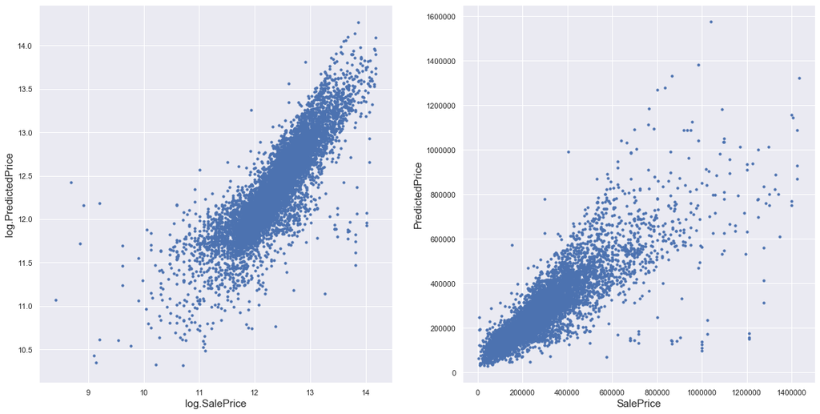

```python
random_state = 1
DATA  = sub_df.to_numpy()
DATA[:,0:2] = np.log(DATA[:,0:2])
################################
X, y = np.c_[DATA[:,1], DATA[:,2], DATA[:,3],\
             DATA[:,4], DATA[:,7],
             DATA[:,8], DATA[:,9], DATA[:,10],
             DATA[:,14]], DATA[:,0]
print(X.shape)
x_train, x_test, y_train, y_test = train_test_split(X, y, test_size = test_size, random_state = random_state)
reg = MultiLinearRegressor()
reg.fit(x_train, y_train)
y_hat = reg.predict(x_test)
print('R2: {:.3f}, MSE: {:.3f}, Acc: {:.3f}'.format(r_square(np.exp(y_test), np.exp(y_hat)),
                                                    mean_square_error(y_hat, y_test),
                                                    regressionAcc(np.exp(y_test), np.exp(y_hat))))
plt.figure(figsize = (20, 10))
plt.subplot(121)
plt.scatter(y_test, y_hat, s = 10)
plt.xlabel('log.SalePrice', fontsize = 15)
plt.ylabel('log.PredictedPrice', fontsize = 15)
plt.subplot(122)
plt.scatter(np.exp(y_test), np.exp(y_hat), s = 10)
plt.xlabel('SalePrice', fontsize = 15)
plt.ylabel('PredictedPrice', fontsize = 15)
```

```
-3806.8430050049087
```

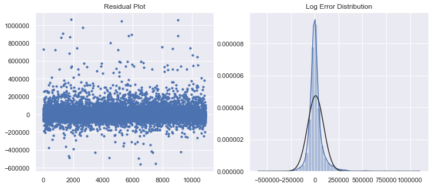

```python
error = np.exp(y_test) - np.exp(y_hat)
plt.figure(figsize =(12, 5))
plt.subplot(121)
plt.scatter(np.arange(len(error)), error, s = 10)
plt.title('Residual Plot')
plt.subplot(122)
sns.distplot(error, fit = norm)
plt.title('Log Error Distribution')
print(np.mean(1 - np.abs(error)/y_test))
```

1: 'SQFT'  
2: 'CLASS'  
3: 'GARAGECAPA'  
4: 'PATIONUMBE'  
7: 'p_Cat'  
8: 'QUALITY'  
9: 'LAT'  
10: 'LON'  
14: 'W0'

```python
num_cols = ['SalePrice', 'SQFT', 'CLASS', 'GARAGECAPA', 'PATIONUMBE', 'p_Cat', 'QUALITY', 'LAT', 'LON']
num_cols.remove('SalePrice')
corr_coef = []
for c in num_cols:
    cc = np.corrcoef(df[c].values, df['SalePrice'].values)[0, 1]
    corr_coef.append(cc)
```

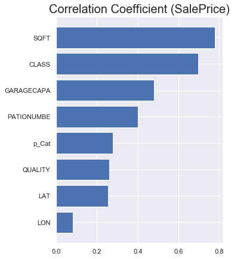

```python
df_cc = pd.DataFrame({'attr': num_cols, 'corr_coef': corr_coef})
df_cc = df_cc.sort_values(by = 'corr_coef')
plt.figure(figsize = (5, 7))
plt.barh(np.arange(len(df_cc)), df_cc['corr_coef'].values)
plt.yticks(np.arange(len(df_cc)), labels = df_cc['attr'].values)
plt.title('Correlation Coefficient (SalePrice)', fontsize = 20)
```

# Final Result

```python
num_cols = ['SQFT', 'CLASS', 'GARAGECAPA', 'PATIONUMBE', 'p_Cat', 'QUALITY', 'LAT', 'LON', 'W0']
w_df = pd.DataFrame({'Features': num_cols, 'Parameters': reg.weights.round(3)})
w_df
```

|  | Features | Parameters |
| --- | --- | --- |
| 0 | SQFT | 0.666 |
| 1 | CLASS | 0.271 |
| 2 | GARAGECAPA | 0.039 |
| 3 | PATIONUMBE | 0.033 |
| 4 | p_Cat | 0.004 |
| 5 | QUALITY | 0.121 |
| 6 | LAT | 0.483 |
| 7 | LON | 0.325 |
| 8 | W0 | 26.428 |

# KNN Classification

```python
def accuracy(y, y_hat):
    return np.mean(y == y_hat)

class KNNClassifier():
    def fit(self, X, y):
        self.X = X
        self.y = y.astype(int)
    def predict(self, X, k, epsilon=1e-2):
        N = len(X)
        y_hat = np.zeros(N)
        for i in range(N):
            dist = np.sum((self.X - X[i])**2, axis=1) # find distance
            idx = np.argsort(dist)[:k] # get the data indexes whose distances are the closest
            ws = (np.sqrt(dist[idx]) + epsilon)**-1
            y_hat[i] = np.bincount(self.y[idx], weights=ws).argmax()
        return y_hat
```

```python
llc = df[['LON', 'LAT', 'CLASS']].to_numpy()
kc = KNNClassifier()
kc.fit(llc[:,:-1], llc[:,-1])
```

```python
xmin = df['LON'].min()
xmax = df['LON'].max()
ymin = df['LAT'].min()
ymax = df['LAT'].max()
xx, yy = np.meshgrid(np.linspace(xmin, xmax, 500),
                     np.linspace(ymin, ymax, 500))
pred = kc.predict(np.c_[xx.ravel(), yy.ravel()], k = 5)
```

[figure not shown]

```python
plt.figure(figsize = (12, 10))
# plt.scatter(xx.ravel(), yy.ravel(), c = pred, s = 10, cmap = 'viridis', alpha = 0.2)
plt.contourf(xx, yy, pred.reshape(xx.shape), cmap = 'viridis', alpha = 0.5)
plt.scatter(df['LON'], df['LAT'], c = df['CLASS'], s = 1, cmap = 'viridis')
cb = plt.colorbar()
cb.set_label('p_Cat')
plt.xlim([-111.5, -110.5])
plt.xlabel('LON'); plt.ylabel('LAT')
```

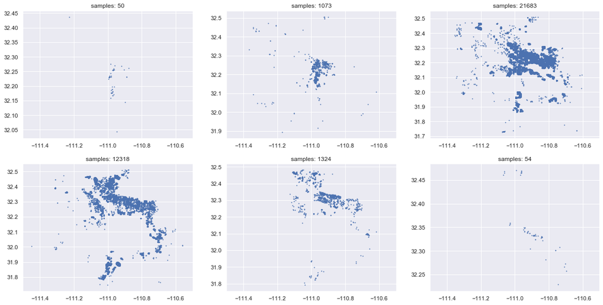

```python
plt.figure(figsize = (20, 10))
for i in range(6):
    plt.subplot(2, 3, i+1)
    plt.scatter(df[df['CLASS'] == i+1]['LON'], df[df['CLASS'] == i+1]['LAT'], s = 1)
    plt.xlim([-111.5, -110.5])
    plt.title('samples: {}'.format(len(df[df['CLASS'] == i+1]['LON'])))
```

# House Price Interval On Map

```python
ddf = sub_df[['SalePrice', 'LAT', 'LON']].copy()
ddf['SalePrice'] = np.log(ddf['SalePrice'])
ddf['class'] = np.zeros(len(ddf))
```

```
   index     SalePrice
0  count  36356.000000
1   mean     12.336240
2    std      0.548398
3    min      8.411833
4    25%     12.013701
5    50%     12.321631
6    75%     12.660328
7    max     14.217637
```

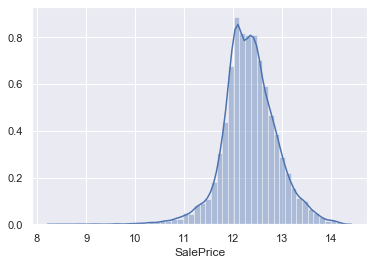

```python
sns.distplot(ddf['SalePrice'])
print(ddf['SalePrice'].describe().reset_index())
u = ddf['SalePrice'].mean()
std = ddf['SalePrice'].std()
```

```python
ddf.loc[ddf['SalePrice'] <= u - 2*std, 'class'] = 1
ddf.loc[(ddf['SalePrice'] <= u - std) & (ddf['SalePrice'] > u - 2*std), 'class'] = 2
ddf.loc[(ddf['SalePrice'] <= u) & (ddf['SalePrice'] > u - std), 'class'] = 3
ddf.loc[ddf['SalePrice'] > u, 'class'] = 4
ddf.loc[ddf['SalePrice'] >= u + std, 'class'] = 5
ddf.loc[ddf['SalePrice'] >= u + 2*std, 'class'] = 6
```

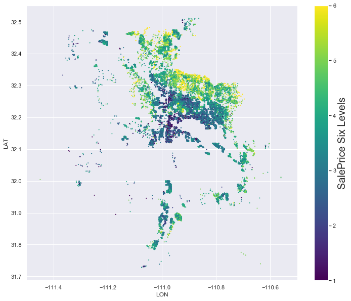

```python
plt.figure(figsize = (12, 10))
plt.scatter(ddf['LON'], ddf['LAT'], c = ddf['class'], s = 1, cmap = 'viridis')
cb = plt.colorbar()
cb.set_label('SalePrice Six Levels', fontsize = 20)
plt.xlim([-111.5, -110.5])
plt.xlabel('LON'); plt.ylabel('LAT')
```